# Lab-13: Regression and Classification Trees

Ives He

# Getting started

In class, we learned how to build a regression tree. In this lab assignment, you will build a classification tree. We will predict a binary outcome, Personal Loan. The loan request is either accepted or it is not.

Start by loading the `tidyverse`, `rpart`, `rpart.plot`, `caret`, and `ggplot2` packages.

```r
library(tidyverse)
library(rpart)
library(rpart.plot)
library(caret)
library(ggplot2)
```

# 1. Data loading and cleaning

Load the dataset `UniversalBank.csv` into a tibble called `bank.df`. Replace all spaces in variable names with a period (‘.’). Drop the `ID` and `ZIP.Code` columns, and inspect the first 6 rows of the dataset. Use `as.factor()` to convert the numeric `Personal.Loan` and `Education` variables into categorical variables.

```r
# Load dataset
bank.df <- read_csv("/Users/iveshe/Library/Mobile Documents/com~apple~CloudDocs/Term 1/FIN 550/Lab/lab-13/UniversalBank.csv")
names(bank.df) <- gsub(" ", ".", names(bank.df))
# drop ID and zip code columns
bank.df <- bank.df %>% select(-ID, -ZIP.Code)
# convert numeric variables to categorical variables
bank.df$Personal.Loan <- as.factor(bank.df$Personal.Loan)
bank.df$Education <- as.factor(bank.df$Education)
str(bank.df)
```

```
## tibble [5,000 × 12] (S3: tbl_df/tbl/data.frame)
##  $ Age               : num [1:5000] 25 45 39 35 35 37 53 50 35 34 ...
##  $ Experience        : num [1:5000] 1 19 15 9 8 13 27 24 10 9 ...
##  $ Income            : num [1:5000] 49 34 11 100 45 29 72 22 81 180 ...
##  $ Family            : num [1:5000] 4 3 1 1 4 4 2 1 3 1 ...
##  $ CCAvg             : num [1:5000] 1.6 1.5 1 2.7 1 0.4 1.5 0.3 0.6 8.9 ...
##  $ Education         : Factor w/ 3 levels "1","2","3": 1 1 1 2 2 2 2 3 2 3 ...
##  $ Mortgage          : num [1:5000] 0 0 0 0 0 155 0 0 104 0 ...
##  $ Personal.Loan     : Factor w/ 2 levels "0","1": 1 1 1 1 1 1 1 1 1 2 ...
##  $ Securities.Account: num [1:5000] 1 1 0 0 0 0 0 0 0 0 ...
##  $ CD.Account        : num [1:5000] 0 0 0 0 0 0 0 0 0 0 ...
##  $ Online            : num [1:5000] 0 0 0 0 0 1 1 0 1 0 ...
##  $ CreditCard        : num [1:5000] 0 0 0 0 1 0 0 1 0 0 ...
```

# 2. Build a classification tree

## 2a.

Build a classification tree using `rpart()`, and assign it to an object called `bank.tree`. Because this is a classification tree, we will specify `method="class"` as an argument. In addition, set `cp=0`, and do not limit the depth of the tree. Finally, display the number of leaves in the tree.

```r
# Build the tree
set.seed(1)
bank.tree <- rpart(Personal.Loan ~ ., data = bank.df, method = "class", cp = 0)

# Number of leaves
num_leaves <- sum(bank.tree$frame$var == "<leaf>")
print(paste("Number of leaves in the tree:", num_leaves))
```

```
## [1] "Number of leaves in the tree: 15"
```

## 2b.

Plot the tree object using the `prp()` command used in class.

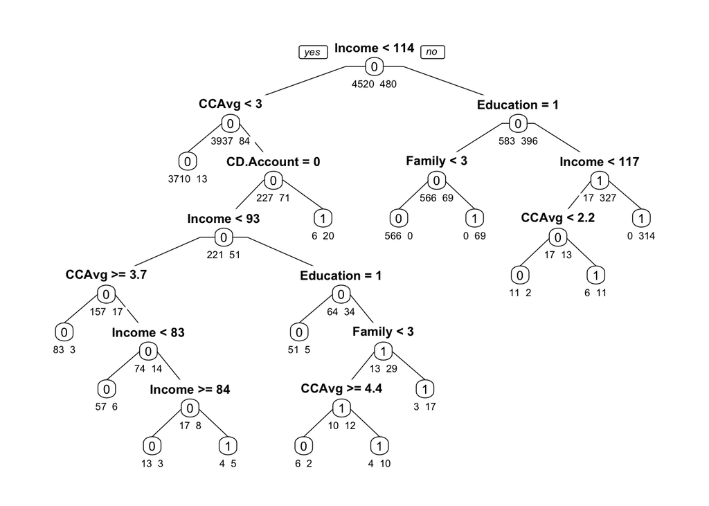

```r
prp(bank.tree, type = 1, extra = 1, under = TRUE, varlen = -10)
```

**Question**: What do the numbers below the leaves represent?

**Answer**: The numbers below leaves show class distribution: first is count for class 0, second is count for class 1, representing how many samples fall into each class at that node.

## 2c.

Plot the tree object using the `plot()` and `text()` commands. If you are able to create a tree plot that is readable and looks nice, let the professor know!

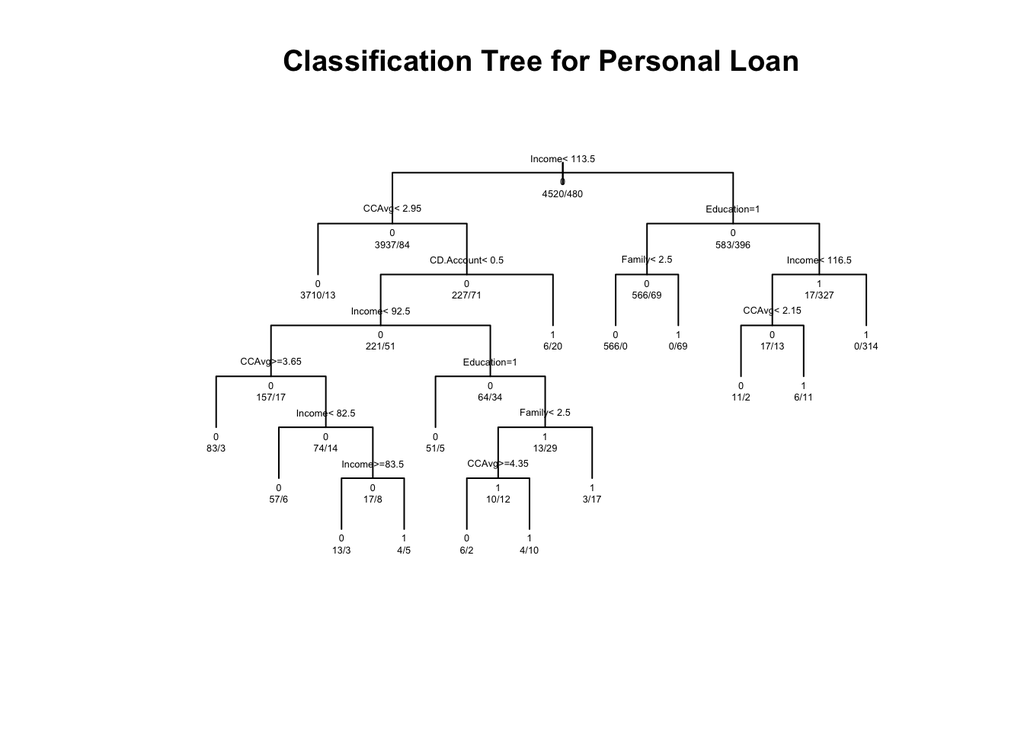

```r
par(mar = c(5, 4, 4, 2) + 0.1)


plot(bank.tree, uniform = TRUE, main = "Classification Tree for Personal Loan", compress = TRUE, margin = 0.1)

text(bank.tree, use.n = TRUE, all = TRUE, cex = 0.4, pretty = 0)
```

# 3. Prune the tree

## 3a.

What is the optimal alpha? What is the cross-validated mean-squared error associated with that alpha?

```r
cp.table <- bank.tree$cptable

# Minimum CV MSE
min_cv_mse <- min(cp.table[, "xerror"])
print(paste("Minimum CV MSE:", min_cv_mse))
```

```
## [1] "Minimum CV MSE: 0.135416666666667"
```

```r
# Optimal alpha
optimal_alpha <- cp.table[which.min(cp.table[, "xerror"]), "CP"]
print(paste("Optimal alpha:", optimal_alpha))
```

```
## [1] "Optimal alpha: 0.00416666666666667"
```

## 3b.

Use the optimal alpha to prune the tree. Create a plot of the pruned tree using `prp`, and calculate how many leaves the plot has.

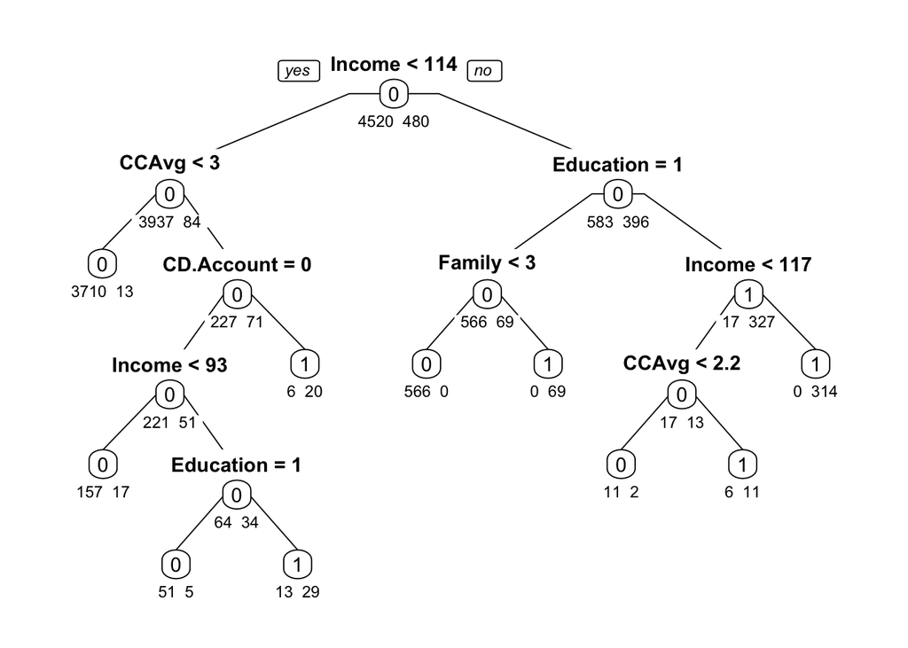

```r
# Prune tree
pruned.tree <- prune(bank.tree, cp = optimal_alpha)

# Pruned tree plot
prp(pruned.tree, type = 1, extra = 1, under = TRUE, varlen = -10)
```

```r
# Number of leaves
num_leaves_pruned <- sum(pruned.tree$frame$var == "<leaf>")
print(paste("Number of leaves in the pruned tree:", num_leaves_pruned))
```

```
## [1] "Number of leaves in the pruned tree: 10"
```

# 4. Make predictions and compare to logistic regression

## 4a.

Use the pruned tree to predict the outcome variable, `Personal.Loan`. Use the `predict()` function, and specify `type="class"`. Confirm that the number of predictions matches the number of observations in the dataset.

```r
# Prediction
set.seed(1)
yhat.tree <- predict(pruned.tree, bank.df, type = "class")

print(paste("Number of predictions:", length(yhat.tree)))
```

```
## [1] "Number of predictions: 5000"
```

```r
print(paste("Number of observations:", nrow(bank.df)))
```

```
## [1] "Number of observations: 5000"
```

## 4b.

Using the function `confusionMatrix()`, create a confusion matrix to assess the quality of the tree predictions. Store it in an object, `cm.tree`, and display it.

```r
# Confusion Matrix
cm.tree <- confusionMatrix(yhat.tree, bank.df$Personal.Loan)
print(cm.tree)
```

```
## Confusion Matrix and Statistics
##
##           Reference
## Prediction    0    1
##          0 4495   37
##          1   25  443
##
##                Accuracy : 0.9876
##                  95% CI : (0.9841, 0.9905)
##     No Information Rate : 0.904
##     P-Value [Acc > NIR] : <2e-16
##
##                   Kappa : 0.9278
##
##  Mcnemar's Test P-Value : 0.1624
##
##             Sensitivity : 0.9945
##             Specificity : 0.9229
##          Pos Pred Value : 0.9918
##          Neg Pred Value : 0.9466
##              Prevalence : 0.9040
##          Detection Rate : 0.8990
##    Detection Prevalence : 0.9064
##       Balanced Accuracy : 0.9587
##
##        'Positive' Class : 0
##
```

## 4b.

Use `glm()` to estimate a logistic regression of `Personal.Loan` on the other variables in the `bank.df` dataset. Store the vector of predicted probabilities in `yhat.logit.prob`. Store the vector of predicted classifications (0/1) in `yhat.logit`.

```r
# Logistic regression
logit <- glm(Personal.Loan ~ ., data = bank.df, family = binomial)

# Logistic predictions
yhat.logit.prob <- predict(logit, bank.df, type = "response")
yhat.logit <- as.factor(ifelse(yhat.logit.prob > 0.5, 1, 0))
```

## 4c.

Create a confusion matrix to assess the quality of the logit predictions. Store it in an object, `cm.logit`, and display it.

```r
# Logit confusion matrix
cm.logit <- confusionMatrix(yhat.logit, bank.df$Personal.Loan)
print(cm.logit)
```

```
## Confusion Matrix and Statistics
##
##           Reference
## Prediction    0    1
##          0 4471  156
##          1   49  324
##
##                Accuracy : 0.959
##                  95% CI : (0.9531, 0.9643)
##     No Information Rate : 0.904
##     P-Value [Acc > NIR] : < 2.2e-16
##
##                   Kappa : 0.7376
##
##  Mcnemar's Test P-Value : 1.328e-13
##
##             Sensitivity : 0.9892
##             Specificity : 0.6750
##          Pos Pred Value : 0.9663
##          Neg Pred Value : 0.8686
##              Prevalence : 0.9040
##          Detection Rate : 0.8942
##    Detection Prevalence : 0.9254
##       Balanced Accuracy : 0.8321
##
##        'Positive' Class : 0
##
```

**Question**: Use the output of the confusion matrices to evaluate which model (classification tree or logit) does a better job at prediction in this setting. Your answer should include a discussion of false positives and false negatives.

**Answer**:

The classification tree has higher accuracy (0.9876) compared to the logistic regression (0.959), with a better balance between sensitivity and specificity. Logistic regression has more false positives (156) and lower specificity (0.6750), while the classification tree shows fewer misclassifications overall, making it the better model.